# Tilastollinen Oppimisen Jatkokurssi Round 5

## Exercise 1

*ISLR 6.9: In this exercise, we will predict the number of applications received using the other variables in the College data set.*

#### (a)

*Split the data set into a training set and a test set.*

Using the same splits as for Round 1.

```r
library(ISLR)
College
```

|  | Private | Apps | Accept | Enroll | Top10perc | Top25perc | F.Undergrad | P.Undergrad | Outstate | Room.Board | Books | Personal | PhD | Terminal | S.F.Ratio | perc.alumni | Expend | Grad.Rate |
| --- | --- | --- | --- | --- | --- | --- | --- | --- | --- | --- | --- | --- | --- | --- | --- | --- | --- | --- |
| Abilene Christian University | Yes | 1660 | 1232 | 721 | 23 | 52 | 2885 | 537 | 7440 | 3300 | 450 | 2200 | 70 | 78 | 18.1 | 12 | 7041 | 60 |
| Adelphi University | Yes | 2186 | 1924 | 512 | 16 | 29 | 2683 | 1227 | 12280 | 6450 | 750 | 1500 | 29 | 30 | 12.2 | 16 | 10527 | 56 |
| Adrian College | Yes | 1428 | 1097 | 336 | 22 | 50 | 1036 | 99 | 11250 | 3750 | 400 | 1165 | 53 | 66 | 12.9 | 30 | 8735 | 54 |
| Agnes Scott College | Yes | 417 | 349 | 137 | 60 | 89 | 510 | 63 | 12960 | 5450 | 450 | 875 | 92 | 97 | 7.7 | 37 | 19016 | 59 |
| Alaska Pacific University | Yes | 193 | 146 | 55 | 16 | 44 | 249 | 869 | 7560 | 4120 | 800 | 1500 | 76 | 72 | 11.9 | 2 | 10922 | 15 |
| Albertson College | Yes | 587 | 479 | 158 | 38 | 62 | 678 | 41 | 13500 | 3335 | 500 | 675 | 67 | 73 | 9.4 | 11 | 9727 | 55 |
| Albertus Magnus College | Yes | 353 | 340 | 103 | 17 | 45 | 416 | 230 | 13290 | 5720 | 500 | 1500 | 90 | 93 | 11.5 | 26 | 8861 | 63 |
| Albion College | Yes | 1899 | 1720 | 489 | 37 | 68 | 1594 | 32 | 13868 | 4826 | 450 | 850 | 89 | 100 | 13.7 | 37 | 11487 | 73 |
| Albright College | Yes | 1038 | 839 | 227 | 30 | 63 | 973 | 306 | 15595 | 4400 | 300 | 500 | 79 | 84 | 11.3 | 23 | 11644 | 80 |
| Alderson-Broaddus College | Yes | 582 | 498 | 172 | 21 | 44 | 799 | 78 | 10468 | 3380 | 660 | 1800 | 40 | 41 | 11.5 | 15 | 8991 | 52 |

[output cut: 767 more lines]

```r
N = 777
K = 155
set.seed(777)
test = sample(seq(N), K, replace=FALSE)
train=seq(N)[-test]
```

#### (e)

*Fit a PCR model on the training set, with M chosen by crossvalidation. Report the test error obtained, along with the value of M selected by cross-validation*

```
Data:   X dimension: 622 17
    Y dimension: 622 1
Fit method: svdpc
Number of components considered: 17

VALIDATION: RMSEP
Cross-validated using 10 random segments.
       (Intercept)  1 comps  2 comps  3 comps  4 comps  5 comps  6 comps  7 comps
CV            3343     3349     1670     1675     1389     1262     1243     1238
adjCV         3343     3349     1669     1675     1372     1250     1241     1237
       8 comps  9 comps  10 comps  11 comps  12 comps  13 comps  14 comps  15 comps
CV        1214     1167      1168      1164      1163      1170      1171      1179
adjCV     1213     1166      1166      1162      1161      1168      1169      1177
       16 comps  17 comps
CV         1037      1024
adjCV      1035      1021

TRAINING: % variance explained
       1 comps  2 comps  3 comps  4 comps  5 comps  6 comps  7 comps  8 comps  9 comps
X     31.49570    57.04    64.09    69.86    75.18    80.26    83.95    87.26    90.33
Apps   0.01781    75.25    75.25    83.72    86.59    86.60    86.72    87.29    88.28
      10 comps  11 comps  12 comps  13 comps  14 comps  15 comps  16 comps  17 comps
X        92.79     94.96     96.86     97.96     98.87     99.42     99.82    100.00
Apps     88.39     88.49     88.56     88.56     88.57     88.57     91.16     91.55
```

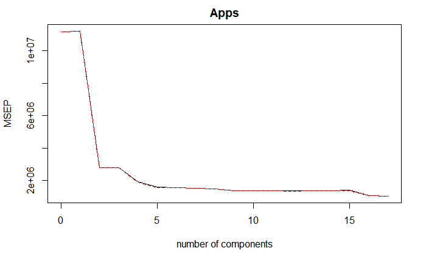

```r
library(pls)
pcr.fit = pcr(Apps ~ ., data = College[train, ], scale=TRUE, validation="CV")
summary(pcr.fit); validationplot(pcr.fit, val.type="MSEP")
```

The best Cross-validation error is when M = 17 e.g. using reglar least squares regression. There is howeever a sharp bend at M = 2 and the value at M = 5 is almost the same as for M = 15. Let’s check both.

```r
pcr.2.pred = predict(pcr.fit, newdata = College[test, ], ncomp = 2)
pcr.5.pred = predict(pcr.fit, newdata = College[test, ], ncomp = 5)
pcr.17.pred = predict(pcr.fit, newdata = College[test, ], ncomp = 17)
mean((pcr.2.pred - College[test, "Apps"])^2); mean((pcr.5.pred - College[test, "Apps"])^2); mean((pcr.17.pred - College[test, "Apps"])^2)
```

```
[1] 8950044
[1] 5727835
[1] 1932994
```

#### (f)

*Fit a PLS model on the training set, with M chosen by crossvalidation. Report the test error obtained, along with the value of M selected by cross-validation.*

```
Data:   X dimension: 622 17
    Y dimension: 622 1
Fit method: kernelpls
Number of components considered: 17

VALIDATION: RMSEP
Cross-validated using 10 random segments.
       (Intercept)  1 comps  2 comps  3 comps  4 comps  5 comps  6 comps  7 comps
CV            3343     1506     1154     1145     1130     1073     1045     1033
adjCV         3343     1504     1143     1142     1125     1062     1040     1029
       8 comps  9 comps  10 comps  11 comps  12 comps  13 comps  14 comps  15 comps
CV        1031     1026      1028      1027      1028      1028      1028      1028
adjCV     1028     1024      1025      1024      1025      1025      1025      1025
       16 comps  17 comps
CV         1028      1028
adjCV      1025      1025

TRAINING: % variance explained
      1 comps  2 comps  3 comps  4 comps  5 comps  6 comps  7 comps  8 comps  9 comps
X       25.40    31.16    58.50    65.57    67.87    71.79    76.11    80.80    82.93
Apps    80.31    88.70    88.98    89.85    91.01    91.41    91.47    91.49    91.52
      10 comps  11 comps  12 comps  13 comps  14 comps  15 comps  16 comps  17 comps
X        84.69     87.16     90.42     93.14     95.96     97.62     98.90    100.00
Apps     91.54     91.55     91.55     91.55     91.55     91.55     91.55     91.55
```

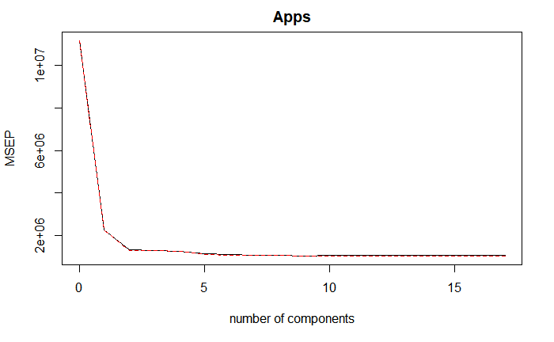

```r
library(pls)
plsr.fit = plsr(Apps ~ ., data = College[train, ], scale=TRUE, validation="CV")
summary(plsr.fit); validationplot(plsr.fit, val.type="MSEP")
```

```r
plsr.2.pred = predict(plsr.fit, newdata = College[test, ], ncomp = 2)
plsr.11.pred = predict(plsr.fit, newdata = College[test, ], ncomp = 11)
mean((plsr.2.pred - College[test, "Apps"])^2); mean((plsr.11.pred - College[test, "Apps"])^2)
```

```
[1] 4925836
[1] 1942386
```

Comparing to Round 1’s results: OLS: 1932994 Ridge: 1933104 Lasso: 1934333

It seems like the Lasso model gives the simplest model with the best test-error (two variables are left out, test-error similar to the lowest test error, 1932994 for OLS). The PCR-model performed very poorly (except for with M = 17 but this is the same as normal OLS) while the PLSR model performed reasonably well.

## Exercise 2

*ISLR 6.11: We will now try to predict per capita crime rate in the Boston data set. Now using PCR.*

#### (a)

*Try out some of the regression methods explored in this chapter, such as best subset selection, the lasso, ridge regression, and PCR. Present and discuss results for the approaches that you consider.*

Loading data and splitting into training- and test-sets

```r
library(MASS)
Boston
```

|  | crim | zn | indus | chas | nox | rm | age | dis | rad | tax | ptratio | black | lstat | medv |
| --- | --- | --- | --- | --- | --- | --- | --- | --- | --- | --- | --- | --- | --- | --- |
| 1 | 0.00632 | 18.0 | 2.31 | 0 | 0.5380 | 6.575 | 65.2 | 4.0900 | 1 | 296 | 15.3 | 396.90 | 4.98 | 24.0 |
| 2 | 0.02731 | 0.0 | 7.07 | 0 | 0.4690 | 6.421 | 78.9 | 4.9671 | 2 | 242 | 17.8 | 396.90 | 9.14 | 21.6 |
| 3 | 0.02729 | 0.0 | 7.07 | 0 | 0.4690 | 7.185 | 61.1 | 4.9671 | 2 | 242 | 17.8 | 392.83 | 4.03 | 34.7 |
| 4 | 0.03237 | 0.0 | 2.18 | 0 | 0.4580 | 6.998 | 45.8 | 6.0622 | 3 | 222 | 18.7 | 394.63 | 2.94 | 33.4 |
| 5 | 0.06905 | 0.0 | 2.18 | 0 | 0.4580 | 7.147 | 54.2 | 6.0622 | 3 | 222 | 18.7 | 396.90 | 5.33 | 36.2 |
| 6 | 0.02985 | 0.0 | 2.18 | 0 | 0.4580 | 6.430 | 58.7 | 6.0622 | 3 | 222 | 18.7 | 394.12 | 5.21 | 28.7 |
| 7 | 0.08829 | 12.5 | 7.87 | 0 | 0.5240 | 6.012 | 66.6 | 5.5605 | 5 | 311 | 15.2 | 395.60 | 12.43 | 22.9 |
| 8 | 0.14455 | 12.5 | 7.87 | 0 | 0.5240 | 6.172 | 96.1 | 5.9505 | 5 | 311 | 15.2 | 396.90 | 19.15 | 27.1 |
| 9 | 0.21124 | 12.5 | 7.87 | 0 | 0.5240 | 5.631 | 100.0 | 6.0821 | 5 | 311 | 15.2 | 386.63 | 29.93 | 16.5 |
| 10 | 0.17004 | 12.5 | 7.87 | 0 | 0.5240 | 6.004 | 85.9 | 6.5921 | 5 | 311 | 15.2 | 386.71 | 17.10 | 18.9 |

[output cut: 496 more lines]

```r
N = 506
K = 101
set.seed(777)
test = sample(seq(N), K, replace=FALSE)
train=seq(N)[-test]
```

Fitting a PCR model with M chosen by cross-validation

```
Data:   X dimension: 405 13
    Y dimension: 405 1
Fit method: svdpc
Number of components considered: 13

VALIDATION: RMSEP
Cross-validated using 10 random segments.
       (Intercept)  1 comps  2 comps  3 comps  4 comps  5 comps  6 comps  7 comps
CV           7.941    6.406    6.389    6.016    5.914    5.952     5.99    5.990
adjCV        7.941    6.402    6.386    6.009    5.907    5.946     5.98    5.981
       8 comps  9 comps  10 comps  11 comps  12 comps  13 comps
CV       5.810    5.781     5.775      5.74     5.729     5.646
adjCV    5.796    5.771     5.766      5.73     5.718     5.635

TRAINING: % variance explained
      1 comps  2 comps  3 comps  4 comps  5 comps  6 comps  7 comps  8 comps  9 comps
X       48.46    60.32    69.68    76.69    82.81    87.96    91.14    93.46    95.40
crim    35.95    36.35    44.44    45.96    45.99    46.27    46.43    49.65    50.09
      10 comps  11 comps  12 comps  13 comps
X        97.04     98.50     99.51    100.00
crim     50.24     50.77     51.37     52.82
```

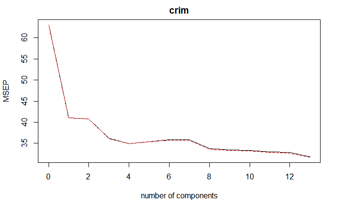

```r
library(pls)
crime.fit = pcr(crim ~ ., data = Boston[train, ], scale=TRUE, validation="CV")
summary(crime.fit); validationplot(crime.fit, val.type="MSEP")
```

Setting M = 4 seems to yield a local minimum in cross-validation error. The full model (OLS) performs the best. Another alternative could be setting M = 8 or M = 1 (will probably not perform well).

#### (b)

*Propose a model (or set of models) that seem to perform well on this data set, and justify your answer. Make sure that you are evaluating model performance using validation set error, crossvalidation, or some other reasonable alternative, as opposed to using training error.*

Let’s check M = 1, M = 4, M = 8 and M = 13.

```r
crime.1.pred = predict(crime.fit, newdata = Boston[test, ], ncomp = 1)
crime.4.pred = predict(crime.fit, newdata = Boston[test, ], ncomp = 4)
crime.8.pred = predict(crime.fit, newdata = Boston[test, ], ncomp = 8)
crime.13.pred = predict(crime.fit, newdata = Boston[test, ], ncomp = 13)
mean((crime.1.pred - Boston[test, "crim"])^2); mean((crime.4.pred - Boston[test, "crim"])^2); mean((crime.8.pred - Boston[test, "crim"])^2); mean((crime.13.pred - Boston[test, "crim"])^2);
```

```
[1] 95.23256
[1] 88.5206
[1] 87.74105
[1] 85.41884
```

Based on test-set error the full model (OLS) performs the best. This was also to be expected from the earlier cross-validation.

#### (c)

*Does your chosen model involve all of the features in the data set? Why or why not?*

Yes, it is equal to standard OLS.

## Exercise 3

*ISLR 10.3: . In this problem, you will perform K-means clustering manually, with K = 2, on a small example with n = 6 observations and p = 2 features. The observations are as follows.* Obs. X1 X2 1 1 4 2 1 3 3 0 4 4 5 1 5 6 2 6 4 0

#### (a)

*Plot the observations.*

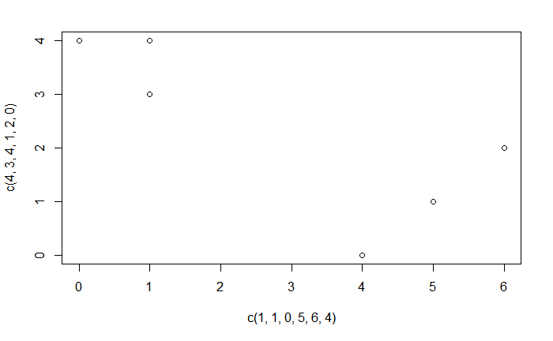

```r
plot(x = c(1, 1, 0, 5, 6, 4), y = c(4, 3, 4, 1, 2, 0))
```

#### (b)

*Randomly assign a cluster label to each observation. You can use the sample() command in R to do this. Report the cluster labels for each observation.*

```r
sample(c(0,1), size = 6, replace = TRUE)
```

```
[1] 1 0 1 1 0 0
```

Obs. Cluster 1 1 2 0 3 1 4 1 5 0 6 0

#### (c)

*Compute the centroid for each cluster.*

```r
x = c(1, 1, 0, 5, 6, 4)
y = c(4, 3, 4, 1, 2, 0)
cluster0 = c(2, 5, 6)
cluster1 = c(1, 3, 4)
centroidx0 = mean(x[cluster0])
centroidy0 = mean(y[cluster0])
centroidx1 = mean(x[cluster1])
centroidy1 = mean(y[cluster1])
centroid0 = c(centroidx0, centroidy0)
centroid1 = c(centroidx1, centroidy1)
centroid0; centroid1
```

```
[1] 3.666667 1.666667
[1] 2 3
```

#### (d)

*Assign each observation to the centroid to which it is closest, in terms of Euclidean distance. Report the cluster labels for each observation.*

```r
for (i in 1:6) {
  tmp1 = (x[i]-centroid0[1])^2+(y[i]-centroid0[2])^2
  tmp2 = (x[i]-centroid1[1])^2+(y[i]-centroid1[2])^2
  print(paste(c(tmp1, tmp2), sep = ", "))
}
```

```
[1] "12.5555555555556" "2"
[1] "8.88888888888889" "1"
[1] "18.8888888888889" "5"
[1] "2.22222222222222" "13"
[1] "5.55555555555556" "17"
[1] "2.88888888888889" "13"
```

Obs. Cluster 1 1 2 1 3 1 4 0 5 0 6 0

#### (e)

*Repeat (c) and (d) until the answers obtained stop changing.*

```r
x = c(1, 1, 0, 5, 6, 4)
y = c(4, 3, 4, 1, 2, 0)
cluster0 = c(4, 5, 6)
cluster1 = c(1, 2, 3)
centroidx0 = mean(x[cluster0])
centroidy0 = mean(y[cluster0])
centroidx1 = mean(x[cluster1])
centroidy1 = mean(y[cluster1])
centroid0 = c(centroidx0, centroidy0)
centroid1 = c(centroidx1, centroidy1)
for (i in 1:6) {
  tmp1 = (x[i]-centroid0[1])^2+(y[i]-centroid0[2])^2
  tmp2 = (x[i]-centroid1[1])^2+(y[i]-centroid1[2])^2
  print(paste(c(tmp1, tmp2), sep = ", "))
}
```

```
[1] "25"                "0.222222222222222"
[1] "20"                "0.555555555555555"
[1] "34"                "0.555555555555556"
[1] "0"                "25.8888888888889"
[1] "2"                "31.2222222222222"
[1] "2"                "24.5555555555556"
```

Obs. Cluster 1 1 2 1 3 1 4 0 5 0 6 0

Results didn’t change, we are done.

#### (f)

*In your plot from (a), color the observations according to the cluster labels obtained.*

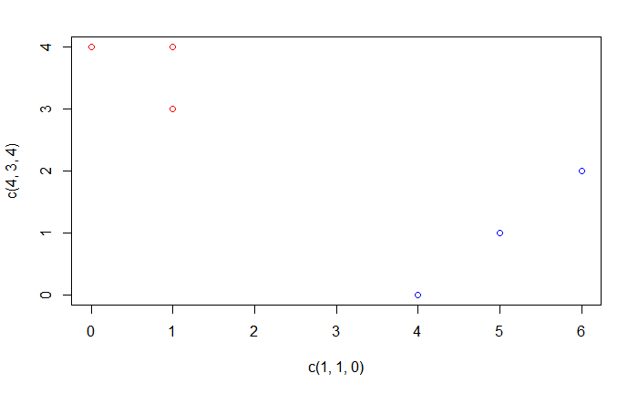

```r
plot(x = c(1, 1, 0), y = c(4, 3, 4), col = "red", xlim = c(0, 6), ylim = c(0, 4))
points(x = c(5, 6, 4), y = c(1, 2, 0), col = "blue")
```

Cluster 0 in blue and cluster 1 in red.